# Customising Quarto Documents

and how to add references

Author

Ina Bornkessel-Schlesewsky

Published

January 25, 2024

## Quarto and markdown basics

You already have quite a bit of experience with creating basic Quarto documents. For your project / report, however, you will want to create a more appealing document. Here are a few more tips to help you get started with this. For more details see https://quarto.org. For much more detail, see the [Quarto User Guide](https://quarto.org/docs/guide/).

### Additional formatting

You can embed additional levels of subheadings by using more hashes. To make text appear **bold** or in *italics* use asterisks. For embedded code, use backticks, e.g. to refer to a function such as `filter()`.

### Dotpoints and lists

- dotpoints can be created easily
- by using asterisks
- to create different levels
  - use tabs
  - here is one more
1. numbered lists
2. work in much the same way

## Customising overall appearance

To customise the overall appearance of your Quarto document, you can change the theme. This document uses the *lux* theme – see the YAML header of the source document to see how to set the theme. A list of themes can be found [here](https://quarto.org/docs/output-formats/html-themes.html).

There are also many other options, e.g. in regard to including a table of contents (or not) and how it is displayed. For html documents, as we are using here, [this section](https://quarto.org/docs/output-formats/html-basics.html) of the Quarto User Guide is very useful in this regard.

## Code chunk behaviour

For your final report, you won’t want code to appear in the output document. You can customise the behaviour of code chunks by setting the `execute` options in the header of the document. For example, to run the code in each chunk without displaying the code itself in the knitted document, set `echo: false`. You can override this overall setting on a chunk-by-chunk basis; see [this section of the user guide](https://quarto.org/docs/output-formats/html-code.html#hiding-code) on how to do this.

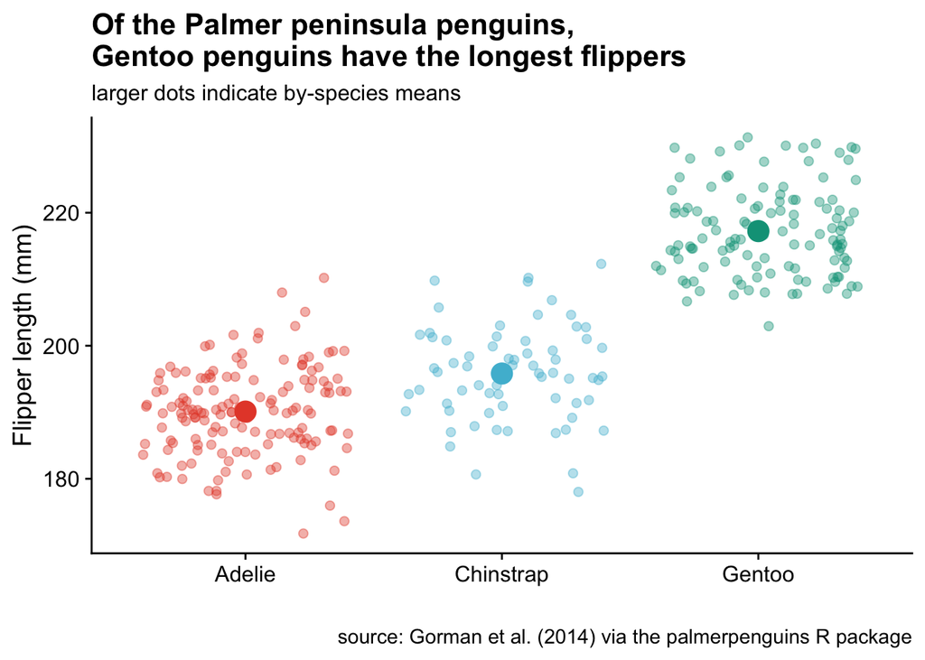

## Including other images

Including other image files is easy! Include your figure caption in square brackets and the location of the image file relative to your Quarto document in round brackets. The location of the image file is called a “path” in technical terms: the easiest option is to have the file in the same folder as your .qmd document and to use a project-based workflow as discussed for reading in csv or other files for data exploration and analysis.

[figure not shown]

Palmer penguins - Artwork by @allison_horst

## Referencing in Quarto

Communicating your results is an essential part of the data science workflow (Wickham & Grolemund, 2017). This of course also involves appropriate referencing. For example, if you’re working with data on the Palmer archipelago penguins, you should mention that these are from Gorman et al. (2014) and provided as an R package by Horst et al. (2020). Note the different format for introducing references in parentheses and outside of them. How you refer to a reference depends on the citation key in your bib file.

To change the referencing style, use a csl file and refer to it in your header. You can find csl files for different referencing styles in the [Zotero style repository](https://www.zotero.org/styles).

For further information, see the [Quarto Manual](https://quarto.org/docs/authoring/footnotes-and-citations.html).

## References

Gorman, K. B., Williams, T. D., & Fraser, W. R. (2014). Ecological Sexual Dimorphism and Environmental Variability within a Community of Antarctic Penguins (Genus Pygoscelis). *PLoS ONE*, *9*(3), e90081. https://doi.org/10.1371/journal.pone.0090081

Horst, A. M., Hill, A. P., & Gorman, K. B. (2020). *Palmerpenguins: Palmer archipelago (antarctica) penguin data* [Manual].

Wickham, H., & Grolemund, G. (2017). *R for Data Science: Import, tidy, transform, visualize, and model data*. O’Reilly Media, Inc.